# Lecture10

# Chi-Square Test, Fishers Exact Test, and Cross Tabulations

## Chi-Square Test

Chi-square test is a parametric method appropriate for testing independence between two categorical variables.

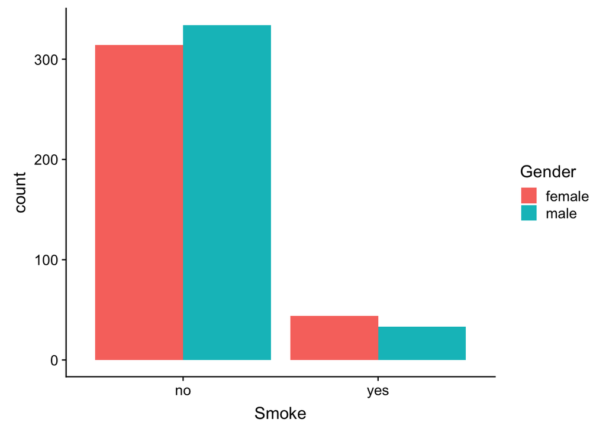

```r
ggplot(data = data_lung) +
  stat_count(mapping = aes(x = Smoke, fill = Gender), position = "dodge")
```

```r
# Ho:the smoking conditions of male and female are independent with each other
(c_table <- table(Gender, Smoke))
```

```
##         Smoke
## Gender    no yes
##   female 314  44
##   male   334  33
```

```r
chi_obj <- chisq.test(c_table, correct = TRUE)
str(chi_obj)
```

```
## List of 9
##  $ statistic: Named num 1.74
##   ..- attr(*, "names")= chr "X-squared"
##  $ parameter: Named int 1
##   ..- attr(*, "names")= chr "df"
##  $ p.value  : num 0.187
##  $ method   : chr "Pearson's Chi-squared test with Yates' continuity correction"
##  $ data.name: chr "c_table"
##  $ observed : 'table' int [1:2, 1:2] 314 334 44 33
##   ..- attr(*, "dimnames")=List of 2
##   .. ..$ Gender: chr [1:2] "female" "male"
##   .. ..$ Smoke : chr [1:2] "no" "yes"
##  $ expected : num [1:2, 1:2] 320 328 38 39
##   ..- attr(*, "dimnames")=List of 2
##   .. ..$ Gender: chr [1:2] "female" "male"
##   .. ..$ Smoke : chr [1:2] "no" "yes"
##  $ residuals: table [1:2, 1:2] -0.334 0.33 0.969 -0.958
##   ..- attr(*, "dimnames")=List of 2
##   .. ..$ Gender: chr [1:2] "female" "male"
##   .. ..$ Smoke : chr [1:2] "no" "yes"
##  $ stdres   : table [1:2, 1:2] -1.44 1.44 1.44 -1.44
##   ..- attr(*, "dimnames")=List of 2
##   .. ..$ Gender: chr [1:2] "female" "male"
##   .. ..$ Smoke : chr [1:2] "no" "yes"
##  - attr(*, "class")= chr "htest"
```

```r
attributes(chi_obj)
```

```
## $names
## [1] "statistic" "parameter" "p.value"   "method"    "data.name" "observed"
## [7] "expected"  "residuals" "stdres"
##
## $class
## [1] "htest"
```

```r
chi_obj$expected
```

```
##         Smoke
## Gender         no      yes
##   female 319.9779 38.02207
##   male   328.0221 38.97793
```

# Fisher’s Exact test

Fisher’s Exact test is a non-parametric alternative to the Chi-Square test.

```r
fisher.test(c_table, conf.int = TRUE, conf.level = 0.99)
```

```
##
##  Fisher's Exact Test for Count Data
##
## data:  c_table
## p-value = 0.1845
## alternative hypothesis: true odds ratio is not equal to 1
## 99 percent confidence interval:
##  0.3625381 1.3521266
## sample estimates:
## odds ratio
##  0.7054345
```

Both test results support the independency of the two category variables.

# Calculate Correlation and Covariance

Pearson’s correlation is a parametric measure of the linear association between 2 numeric variables.

Spearman’s correlation is a non-parametric measure of the monotonic association between 2 numeric variables.

Kendall’s rank correlation is another non-parametric measure of the association, based on the concordance or discordance of x-y pair.

Functions: cor(), cov(), cor.test()

The relationship between Age and LungCap

Scatterplot

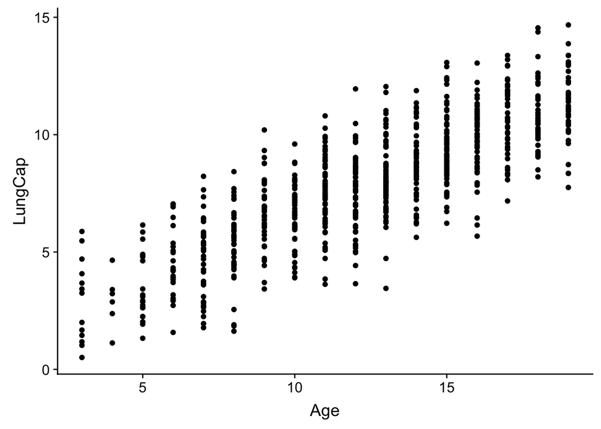

```r
ggplot(data = data_lung, aes(x = Age, y = LungCap)) +
  geom_point()
```

## cor()

```r
cor(Age, LungCap, method = "pearson")  #default method
```

```
## [1] 0.8196749
```

```r
cor(Age, LungCap, method = "spearman")
```

```
## [1] 0.8172464
```

```r
cor(Age, LungCap, method = "kendall")
```

```
## [1] 0.639576
```

## cor.test()

```r
cor.test(Age, LungCap, method = "pearson")  #default method
```

```
##
##  Pearson's product-moment correlation
##
## data:  Age and LungCap
## t = 38.476, df = 723, p-value < 2.2e-16
## alternative hypothesis: true correlation is not equal to 0
## 95 percent confidence interval:
##  0.7942660 0.8422217
## sample estimates:
##       cor
## 0.8196749
```

```r
cor.test(Age, LungCap, method = "pearson", alt = "greater", conf.level = 0.99)  #default method
```

```
##
##  Pearson's product-moment correlation
##
## data:  Age and LungCap
## t = 38.476, df = 723, p-value < 2.2e-16
## alternative hypothesis: true correlation is greater than 0
## 99 percent confidence interval:
##  0.7891778 1.0000000
## sample estimates:
##       cor
## 0.8196749
```

```r
cor.test(Age, LungCap, method = "spearman")  #default method
```

```
##
##  Spearman's rank correlation rho
##
## data:  Age and LungCap
## S = 11607000, p-value < 2.2e-16
## alternative hypothesis: true rho is not equal to 0
## sample estimates:
##       rho
## 0.8172464
```

```r
cor.test(Age, LungCap, method = "spearman", exact = FALSE)  #default method
```

```
##
##  Spearman's rank correlation rho
##
## data:  Age and LungCap
## S = 11607000, p-value < 2.2e-16
## alternative hypothesis: true rho is not equal to 0
## sample estimates:
##       rho
## 0.8172464
```

## cov()

```r
cov(Age,LungCap)
```

```
## [1] 8.738289
```

## correlation matrix

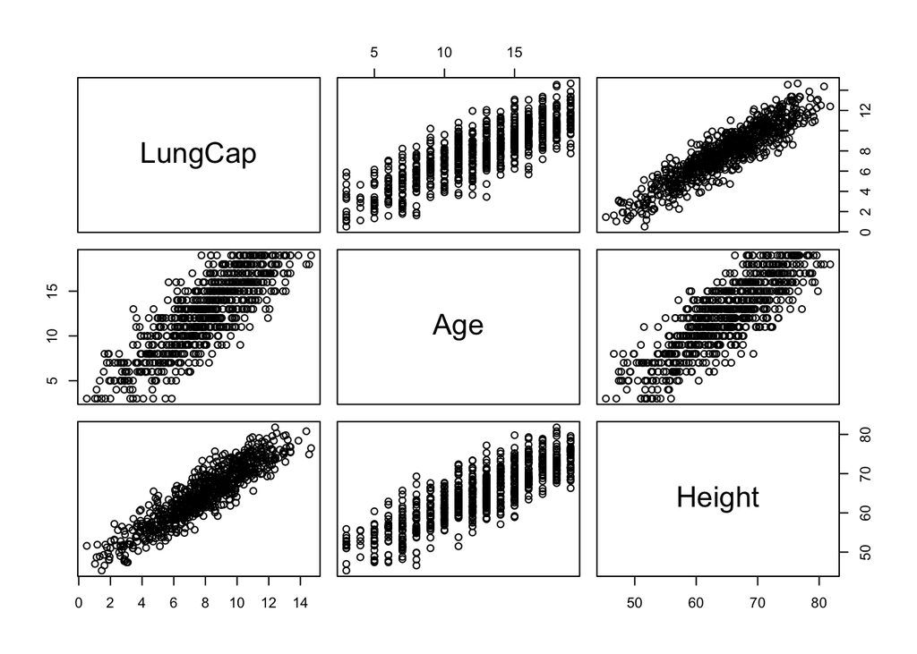

```r
#pairs {graphics}
pairs(data_lung[,1:3])
```

```r
# another package
library(GGally)
```

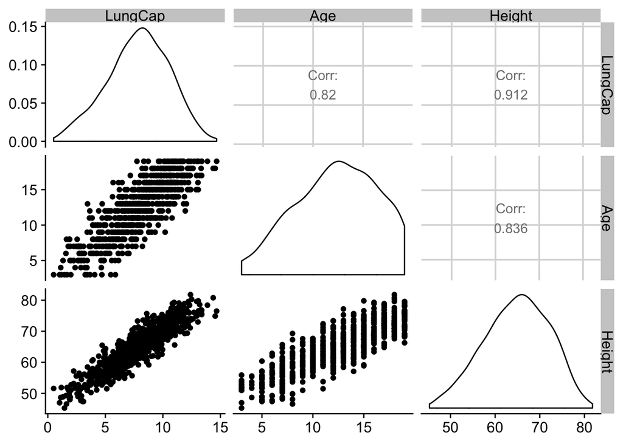

```r
ggpairs(data_lung[,1:3])
```

```r
#correlation matrix
cor(data_lung[,1:3])
```

```
##           LungCap       Age    Height
## LungCap 1.0000000 0.8196749 0.9121873
## Age     0.8196749 1.0000000 0.8357368
## Height  0.9121873 0.8357368 1.0000000
```

# Analysis of Variance (ANOVA) and Multiple Comparisons

ANOVA is a parametric method appropriate for comparing the Means for 2 or more independent populations.

-The data

```r
diamonds
```

```
## # A tibble: 53,940 x 10
##    carat cut       color clarity depth table price     x     y     z
##    <dbl> <ord>     <ord> <ord>   <dbl> <dbl> <int> <dbl> <dbl> <dbl>
##  1 0.23  Ideal     E     SI2      61.5    55   326  3.95  3.98  2.43
##  2 0.21  Premium   E     SI1      59.8    61   326  3.89  3.84  2.31
##  3 0.23  Good      E     VS1      56.9    65   327  4.05  4.07  2.31
##  4 0.290 Premium   I     VS2      62.4    58   334  4.2   4.23  2.63
##  5 0.31  Good      J     SI2      63.3    58   335  4.34  4.35  2.75
##  6 0.24  Very Good J     VVS2     62.8    57   336  3.94  3.96  2.48
##  7 0.24  Very Good I     VVS1     62.3    57   336  3.95  3.98  2.47
##  8 0.26  Very Good H     SI1      61.9    55   337  4.07  4.11  2.53
##  9 0.22  Fair      E     VS2      65.1    61   337  3.87  3.78  2.49
## 10 0.23  Very Good H     VS1      59.4    61   338  4     4.05  2.39
## # ... with 53,930 more rows
```

```r
attach(diamonds, warn.conflicts = FALSE)
levels(cut)
```

```
## [1] "Fair"      "Good"      "Very Good" "Premium"   "Ideal"
```

## plot

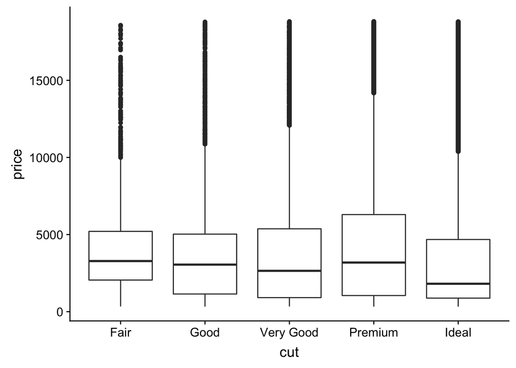

```r
ggplot(data = diamonds, aes(x = cut, y = price)) +
  geom_boxplot()
```

## one-way ANOVA

```r
# Ho: price is the same for all cut
(aov_dmd <- aov(price ~ cut))
```

```
## Call:
##    aov(formula = price ~ cut)
##
## Terms:
##                          cut    Residuals
## Sum of Squares   11041745359 847431390159
## Deg. of Freedom            4        53935
##
## Residual standard error: 3963.847
## Estimated effects may be unbalanced
```

```r
summary(aov_dmd)
```

```
##                Df    Sum Sq   Mean Sq F value Pr(>F)
## cut             4 1.104e+10 2.760e+09   175.7 <2e-16 ***
## Residuals   53935 8.474e+11 1.571e+07
## ---
## Signif. codes:  0 '***' 0.001 '**' 0.01 '*' 0.05 '.' 0.1 ' ' 1
```

```r
attributes(aov_dmd)
```

```
## $names
##  [1] "coefficients"  "residuals"     "effects"       "rank"
##  [5] "fitted.values" "assign"        "qr"            "df.residual"
##  [9] "contrasts"     "xlevels"       "call"          "terms"
## [13] "model"
##
## $class
## [1] "aov" "lm"
```

```r
aov_dmd$coefficients
```

```
## (Intercept)       cut.L       cut.Q       cut.C       cut^4
##   4062.2364   -362.7254   -225.5798   -699.4965   -280.3564
```

The result of the ANOVA test shows that the price is not the same for all kinds of cut.

## Comparing to the regression results

```r
summary(lm(price~cut, data=diamonds))
```

```
##
## Call:
## lm(formula = price ~ cut, data = diamonds)
##
## Residuals:
##    Min     1Q Median     3Q    Max
##  -4258  -2741  -1494   1360  15348
##
## Coefficients:
##             Estimate Std. Error t value Pr(>|t|)
## (Intercept)  4062.24      25.40 159.923  < 2e-16 ***
## cut.L        -362.73      68.04  -5.331  9.8e-08 ***
## cut.Q        -225.58      60.65  -3.719    2e-04 ***
## cut.C        -699.50      52.78 -13.253  < 2e-16 ***
## cut^4        -280.36      42.56  -6.588  4.5e-11 ***
## ---
## Signif. codes:  0 '***' 0.001 '**' 0.01 '*' 0.05 '.' 0.1 ' ' 1
##
## Residual standard error: 3964 on 53935 degrees of freedom
## Multiple R-squared:  0.01286,    Adjusted R-squared:  0.01279
## F-statistic: 175.7 on 4 and 53935 DF,  p-value: < 2.2e-16
```

All the coefficients for the cut are significant, which consists with the above conclusion from the ANOVA test.

## Multiple comparisons for each pair

```r
TukeyHSD(aov_dmd)
```

```
##   Tukey multiple comparisons of means
##     95% family-wise confidence level
##
## Fit: aov(formula = price ~ cut)
##
## $cut
##                          diff         lwr        upr     p adj
## Good-Fair          -429.89331  -740.44880  -119.3378 0.0014980
## Very Good-Fair     -376.99787  -663.86215   -90.1336 0.0031094
## Premium-Fair        225.49994   -59.26664   510.2665 0.1950425
## Ideal-Fair         -901.21579 -1180.57139  -621.8602 0.0000000
## Very Good-Good       52.89544  -130.15186   235.9427 0.9341158
## Premium-Good        655.39325   475.65120   835.1353 0.0000000
## Ideal-Good         -471.32248  -642.36268  -300.2823 0.0000000
## Premium-Very Good   602.49781   467.76249   737.2331 0.0000000
## Ideal-Very Good    -524.21792  -647.10467  -401.3312 0.0000000
## Ideal-Premium     -1126.71573 -1244.62267 -1008.8088 0.0000000
```

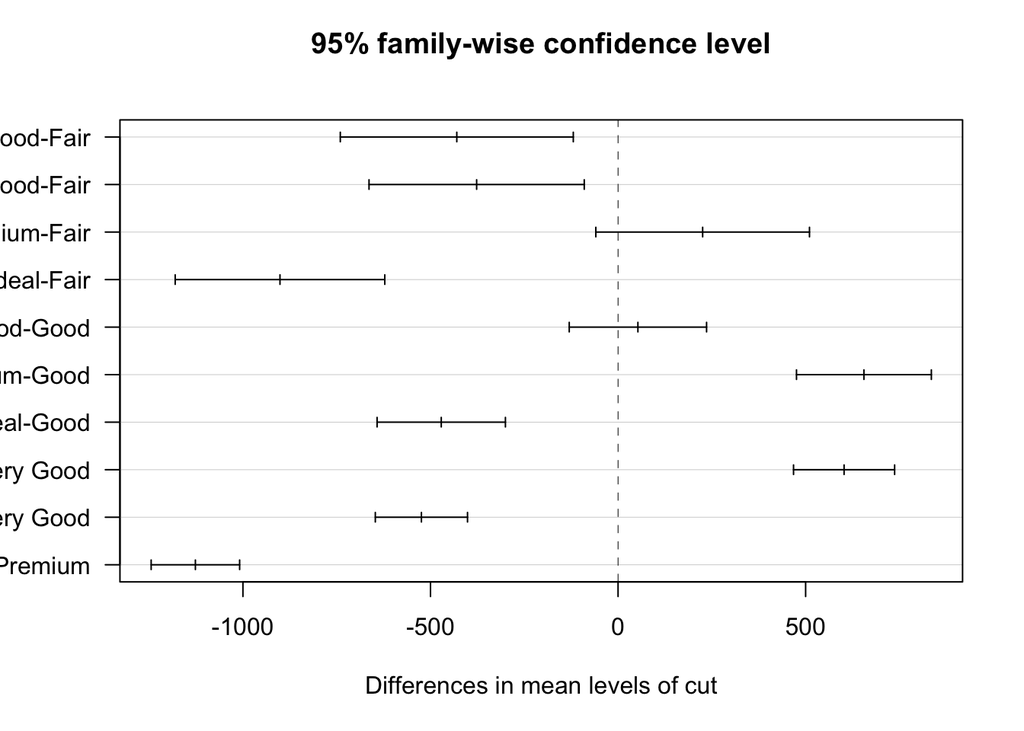

```r
plot(TukeyHSD(aov_dmd),las=1)
```

## Kruskal Wallis one-day analysis of variance

Kruskal Wallis one-way analysis of variance is a non-parametric equivalent to the one-way analysis of variance

```r
kruskal.test(price ~ cut)
```

```
##
##  Kruskal-Wallis rank sum test
##
## data:  price by cut
## Kruskal-Wallis chi-squared = 978.62, df = 4, p-value < 2.2e-16
```